# Moauro et. al., 2023 - Figure 3

Stephanie Hickey

09/7/2023

## Set up

### Make project `figures` directory

```r
figures.dir = "results/figures"
if(!dir.exists(figures.dir)){dir.create(figures.dir)}
```

### Set seed and sources

```r
knitr::opts_knit$set(root.dir = ".")
set.seed(1)
source("./src/scRNA_seq_functions.R")
```

### Load the necessary libraries

```r
library(Seurat)
library(tidyverse)
library(patchwork)
library(viridis)
```

## Figure 3. Identification of Oct4-expressing cells with primitive endoderm character during OSKM reprogramming by single cell RNA-sequencing.

Load Mohammed Data:

- Mohammed cluster enriched genes listed in `data/Mohammed2017_TabS1_set_table.Rdata` are copied from [Table S1](https://ars.els-cdn.com/content/image/1-s2.0-S2211124717309610-mmc2.xlsx) – tab: `SC3 Cluster specific genes` – Columns: `Enriched genes by SC3 clustering for each lineage (All genes)`
- `data/Mohammed2017_seurat.rdata` was generated as per `src/mohammed_preprocessing.Rmd`

```r
# enriched genes
load("data/Mohammed2017_TabS1_set_table.Rdata")

# seurat object
load("data/Mohammed2017_seurat.rdata")
```

### Figure 3A-B: UMAP and over-representation analysis with Mohammed et. al. markers. All cells res 0.70

Load data and pull all cells UMAP dimensions

- `data/Day17_Reprogramming_scRNA_seq_QC_filtered_SeuratObject.Rdata` was generated as per `src/scRNA_scTransform_norm_and_cluster.Rmd`

```r
load("data/Day17_Reprogramming_scRNA_seq_QC_filtered_SeuratObject.Rdata")
all_cells_umap = Embeddings(seuratOb, reduction = "umap")[, 1:2]
```

Change cluster names

```r
seuratOb@meta.data$SCT_snn_res.0.7_figure3 = as.factor(as.numeric(seuratOb@meta.data$SCT_snn_res.0.7))
```

Load marker genes

- `/results/all_cells/SCT_snn_res.0.7_marker_genes.csv` was generated using `src/seuratFindAllMarkers_allRes.R`

```r
res_markers = read.csv("results/all_cells/SCT_snn_res.0.7_marker_genes.csv", header = T, row.names = 1)
```

Change cluster names and save

```r
res_markers$cluster = as.character(res_markers$cluster + 1)
write.csv(res_markers, file = "results/figures/SCT_snn_res.0.7_marker_genes_all_cells_figure3_clusters.csv")
```

Select high confidence markers

```r
getHighConfidenceGenes = function(marker_df){

  hiC =
    marker_df %>%
    filter(avg_log2FC >= .25,
           pct.1 >= .10 | pct.1 >= .10,
           p_val_adj < .001) %>%
    select(gene, cluster) %>%
    rename(Gene = gene, Set = cluster)

  hiC$Set = as.character(hiC$Set)

  return(hiC)
}

hi_conf = getHighConfidenceGenes(res_markers)
```

Pull only genes assayed in both datasets

```r
filterGeneSets = function(reprog_seurat, mohammed_seurat){

  reprog_genes = rownames(reprog_seurat)
  mohammed_genes = rownames(mohammed_seurat)
  background = reprog_genes[reprog_genes %in% mohammed_genes]

  hi_conf =
    hi_conf %>%
    filter(Gene %in% background)

  set_table_filt =
    set_table %>%
    filter(Gene %in% background)

  sets_and_background = list(
    reprog_set = hi_conf,
    mohammed_set = set_table_filt,
    background = background
  )
  return(sets_and_background)
}
```

Perform hypergeometric test

```r
sets_and_background = filterGeneSets(seuratOb, dat)

phyper = phyperOverlapSets(sets_and_background$reprog_set,
                           sets_and_background$mohammed_set,
                           length(sets_and_background$background))

# save shared genes
shared = phyper$intersecting.genes
colnames(shared) = c("ReprgrammingCluster",
                     "MohammedCellType",
                     "SharedGene")

write.csv(shared, "results/figures/all_cells_mohammed_shared_genes.csv", row.names = FALSE)
```

Plot with All cells UMAP dimensions and over-representation heat map

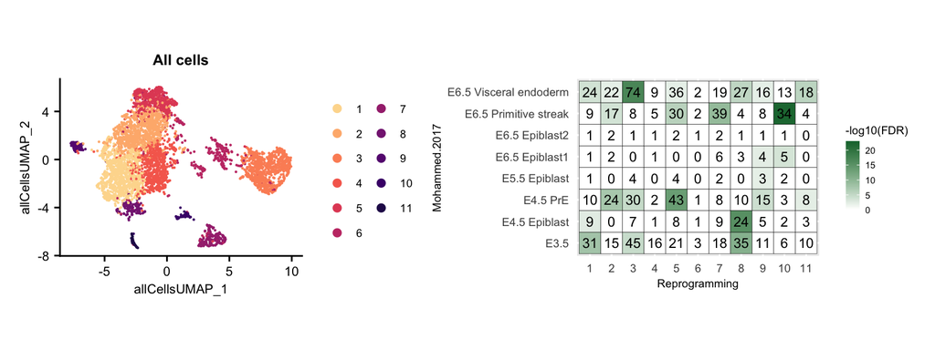

```r
magma = c("#fdda9c", "#feb67c",
          "#fc9065", "#f66c5c", "#e34e65",
          "#c53c74", "#a6317d", "#862781",
          "#671b80", "#491078", "#271258")

plotFig3 = function(res, plot_title) {
  scores = phyper$pval.scores

  scores =
    scores %>%
    group_by(Group1) %>%
    mutate(FDR = p.adjust(Pval, "BH")) %>%
    rename(Reprogramming = Group1,
           Mohammed.2017 = Group2)

  #possible_clusters = unique(scores$Reprogramming)
  nclust = length(unique(scores$Reprogramming))

  scores$FDR[scores$FDR > .01] = 1
  scores$Reprogramming = factor(scores$Reprogramming,
                         levels = unique(scores$Reprogramming))

  plot1 =
    ggplot(scores,
           aes(Reprogramming, Mohammed.2017)) +
           geom_tile(aes(fill = -log10(FDR)),
                     color = "black") +
        #Creating legend
        guides(fill=guide_colorbar(title = "-log10(FDR)",
                                   barheight = 15,
                                   barwidth = 3,
                                   default.unit = "mm")) +
        #Creating color range
        scale_fill_gradientn(colors=c("white",
                                      "#0E7139"),
                             guide="colorbar",
                             limits = c(0, 23)) +
        theme(text = element_text(size = 7),
              axis.text = element_text(size = 7),
              axis.ticks = element_blank()) +
        geom_text(aes(label = nSharedGenes), size = 3) +
        coord_fixed()

  # set the identity
  Idents(object = seuratOb) <- res
  umap_filt = all_cells_umap[colnames(seuratOb),]
  colnames(umap_filt) <- paste0("allCellsUMAP_", 1:2)
  seuratOb[["all.cells.UMAP"]] <- CreateDimReducObject(embeddings = umap_filt,
                                        key = "allCellsUMAP_",
                                        assay = DefaultAssay(seuratOb))
  # cluster plot
  plot2 = DimPlot(seuratOb,
                  reduction = "all.cells.UMAP",
                  label = FALSE,
                  cols = magma[1:nclust],
                  pt.size = .1) +
    guides(color = guide_legend(ncol = 2,
                                override.aes = list(size = 2))) +
    ggtitle(plot_title) +
    theme(plot.title = element_text(hjust = 0.5)) +
    theme(plot.title = element_text(face="bold")) +
    theme(text = element_text(size = 8),
        axis.text = element_text(size = 8))


  fig3_out = plot2 | plot1 #+ plot_layout(heights = c(2,3))
  return(list(fig3_out, plot2, plot1))
}

fig3ab = plotFig3("SCT_snn_res.0.7_figure3", "All cells")
ggsave(fig3ab[[1]], file = "results/figures/fig3ab.png")
fig3ab[[1]]
```

```r
rm(seuratOb, res_markers, hi_conf, sets_and_background, phyper)
```

### Figure 3D: Over-representation analysis between Mohammed et. al. markers and Wamaitha et. al. mESC vs eXEN DE genes.

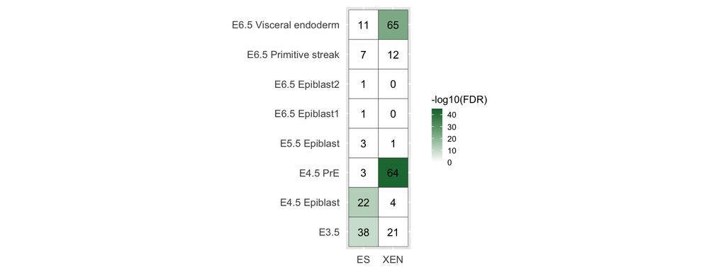

```r
wamaitha_de = read.csv("results/Wamaitha_mESC_vs_eXEN_DE.csv")

wamaitha_genes = wamaitha_de$SYMBOL
mohammed_genes = rownames(dat)

background = wamaitha_genes[wamaitha_genes %in% mohammed_genes]

wamaitha_sig =
  wamaitha_de %>%
  filter(adj.P.Val < .01, SYMBOL %in% background) %>%
  mutate(Set = case_when(
    logFC > 0 ~ "ES",
    logFC < 0 ~ "XEN"
  )) %>%
  select(SYMBOL, Set)

set_table_filt =
  set_table %>%
  filter(Gene %in% background)

phyper = phyperOverlapSets(wamaitha_sig,
                           set_table_filt,
                           length(background))

scores = phyper$pval.scores

  scores =
    scores %>%
    group_by(Group1) %>%
    mutate(FDR = p.adjust(Pval, "BH")) %>%
    rename(ESvsXEN = Group1,
           Mohammed.2017 = Group2)

  scores$FDR[scores$FDR > .01] = 1
  scores$Reprogramming = factor(scores$ESvsXEN,
                         levels = unique(scores$ESvsXEN))

  plot1 =
    ggplot(scores,
           aes(ESvsXEN, Mohammed.2017)) +
           geom_tile(aes(fill = -log10(FDR)),
                     color = "black") +
        #Creating legend
        guides(fill=guide_colorbar(title = "-log10(FDR)",
                                   barheight = 15,
                                   barwidth = 3,
                                   default.unit = "mm")) +
        #Creating color range
        scale_fill_gradientn(colors=c("white",
                                      "#0E7139"),
                             guide="colorbar",
                             limits = c(0, 45)) +
        theme(text = element_text(size = 8),
              axis.text = element_text(size = 8),
              axis.ticks = element_blank(),
              axis.title.x=element_blank(),
              axis.title.y=element_blank()) +
        geom_text(aes(label = nSharedGenes), size = 3) +
        coord_fixed()

ggsave("results/figures/fig3d.png", width = 3, height = 4)
plot1
```

### Figure 3E-F: UMAP and over-representation analysis with Mohammed et. al. markers. Oct4+ cells res 0.70

Load Seurat object

- `data/Day17_Reprogramming_scRNA_seq_Pou5f1_expressing_QC_filtered_SeuratObject.Rdata` was generated as per `src/scRNA_scTransform_norm_and_cluster.Rmd`

```r
load("data/Day17_Reprogramming_scRNA_seq_Pou5f1_expressing_QC_filtered_SeuratObject.Rdata")
```

Change cluster names

```r
seuratOb@meta.data$SCT_snn_res.0.7_figure3 = seuratOb@meta.data$SCT_snn_res.0.7

new_names = LETTERS[1:10]
old_names = as.factor(0:9)

for (i in 1:length(old_names)){

  seuratOb@meta.data$SCT_snn_res.0.7_figure3 =
    gsub(paste0("^(",old_names[i], ")$"),
                new_names[i],
                seuratOb@meta.data$SCT_snn_res.0.7_figure3)

}

seuratOb@meta.data$SCT_snn_res.0.7_figure3 =
  factor(x = seuratOb@meta.data$SCT_snn_res.0.7_figure3, levels = new_names)
```

Load marker genes

- `/results/Pou5f1_expressing_cells/SCT_snn_res.0.7_marker_genes.csv` was generated using `src/seuratFindAllMarkers_allRes.R`

```r
res_markers = read.csv("results/Pou5f1_expressing_cells/SCT_snn_res.0.7_marker_genes.csv", header = T, row.names = 1)
```

Change cluster names and save

```r
new_names = LETTERS[1:10]
old_names = as.factor(0:9)

for (i in 1:length(old_names)){

  res_markers$cluster =
    gsub(paste0("^(",old_names[i], ")$"),
                new_names[i],
                res_markers$cluster)

}

write.csv(res_markers, file = "results/figures/SCT_snn_res.0.7_marker_genes_Pou5f1_expressing_cells_figure3_clusters.csv")
```

Select high confidence markers

```r
hi_conf = getHighConfidenceGenes(res_markers)
```

Perform hypergeometric test

```r
sets_and_background = filterGeneSets(seuratOb, dat)

phyper = phyperOverlapSets(sets_and_background$reprog_set,
                           sets_and_background$mohammed_set,
                           length(sets_and_background$background))

# save shared genes
shared = phyper$intersecting.genes
colnames(shared) = c("ReprgrammingCluster",
                     "MohammedCellType",
                     "SharedGene")

write.csv(shared, "results/figures/Oct4_mohammed_shared_genes.csv", row.names = FALSE)
```

Plot

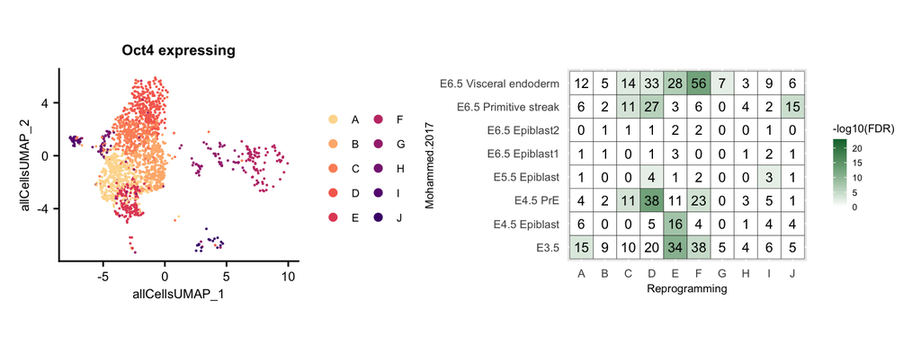

```r
fig3ef = plotFig3("SCT_snn_res.0.7_figure3", "Oct4 expressing")
ggsave(fig3ef[[1]], file = "results/figures/fig3ef.png")
fig3ef[[1]]
```

```r
#rm(seuratOb, res_markers, hi_conf, sets_and_background, phyper)
```

### Figure 3G-H: UMAP and over-representation analysis with Mohammed et. al. markers. Sox2+ cells res 0.70

Load Seurat object

- `data/Day17_Reprogramming_scRNA_seq_Sox2_expressing_QC_filtered_SeuratObject.Rdata` was generated as per `src/scRNA_scTransform_norm_and_cluster.Rmd`

```r
load("data/Day17_Reprogramming_scRNA_seq_Sox2_expressing_QC_filtered_SeuratObject.Rdata")
```

Change cluster names

```r
seuratOb@meta.data$SCT_snn_res.0.7_figure3 = seuratOb@meta.data$SCT_snn_res.0.7

new_names = LETTERS[18:26]
old_names = as.factor(0:8)

for (i in 1:length(old_names)){

  seuratOb@meta.data$SCT_snn_res.0.7_figure3 =
    gsub(paste0("^(",old_names[i], ")$"),
                new_names[i],
                seuratOb@meta.data$SCT_snn_res.0.7_figure3)

}

seuratOb@meta.data$SCT_snn_res.0.7_figure3 =
  factor(x = seuratOb@meta.data$SCT_snn_res.0.7_figure3, levels = new_names)
```

Load marker genes

- `/results/Sox2_expressing_cells/SCT_snn_res.0.7_marker_genes.csv` was generated using `src/seuratFindAllMarkers_allRes.R`

```r
res_markers = read.csv("results/Sox2_expressing_cells/SCT_snn_res.0.7_marker_genes.csv", header = T, row.names = 1)
```

Change cluster names and save

```r
new_names = LETTERS[18:26]
old_names = as.factor(0:8)

for (i in 1:length(old_names)){

  res_markers$cluster =
    gsub(paste0("^(",old_names[i], ")$"),
                new_names[i],
                res_markers$cluster)

}

write.csv(res_markers, file = "results/figures/SCT_snn_res.0.7_marker_genes_Sox2_expressing_cells_figure3_clusters.csv")
```

Select high confidence markers

```r
hi_conf = getHighConfidenceGenes(res_markers)
```

Perform hypergeometric test

```r
sets_and_background = filterGeneSets(seuratOb, dat)

phyper = phyperOverlapSets(sets_and_background$reprog_set,
                           sets_and_background$mohammed_set,
                           length(sets_and_background$background))

# save shared genes
shared = phyper$intersecting.genes
colnames(shared) = c("ReprgrammingCluster",
                     "MohammedCellType",
                     "SharedGene")

write.csv(shared, "results/figures/Sox2_mohammed_shared_genes.csv", row.names = FALSE)
```

Plot

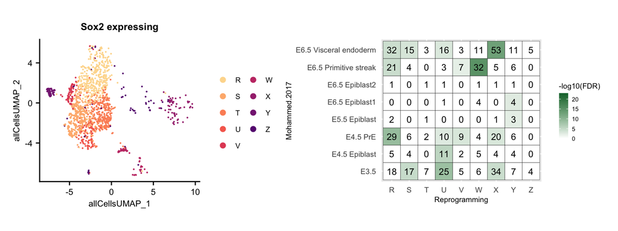

```r
fig3gh = plotFig3("SCT_snn_res.0.7_figure3", "Sox2 expressing")
ggsave(fig3gh[[1]], file = "results/figures/fig3gh.png")

fig3gh[[1]]
```

```r
rm(seuratOb, res_markers, hi_conf, sets_and_background, phyper)
```